# Food_Delivery_App_Data_Analysis_Portfolio

Executive Summary

1. Libraries Import
2. Reading the Data and Initial Inspection
   - 2.1. Loading the Orders Dataset
   - 2.2. Checking the Shape of the Orders Dataset
   - 2.3. Displaying the First Few Rows of the Orders Dataset
   - 2.4. Checking for Missing Values in the Orders Dataset
   - 2.5. Verifying Data Types in the Orders Dataset
   - 2.6. Loading and Inspecting the Restaurants Dataset
3. Data Cleaning
   - 3.1. Consistency Checks
     - 3.1.1. Unique Values
     - 3.1.2. Range Checks
     - 3.1.3. Date and Numeric Value Checks
     - 3.1.4. Non-Numeric Values Check
   - 3.2. Outlier Detection
   - 3.3. Duplicate Detection
4. Exploratory Data Analysis (EDA)
   - 4.1. Which Payment Method is Most Frequently Used?
     - 4.1.1. Data Exploration
     - 4.1.2. Visualization
     - 4.1.3. Findings Documentation
   - 4.2.When Do Customers Order More in a Day?
     - 4.2.1. Data Exploration
     - 4.2.2. Visualization
     - 4.2.3. Findings Documentation
   - 4.3. What is the Average Order Amount per Customer and Does it Vary by Zone?
     - 4.3.1. Data Exploration
     - 4.3.2. Visualiation
     - 4.3.3. Findings Documentation
   - 4.4. How Do Order Amounts Vary Across Different Cuisines?
     - 4.4.1. Data Exploration
     - 4.4.2. Visualization
     - 4.4.3. Findings Documentation
   - 4.5. Is There a Relationship Between In-Demand Restaurants and In-Demand Cuisine?
     - 4.5.1. Data Exploration
     - 4.5.2. Visualization
     - 4.5.3. Findings Documentation
   - 4.6. What Is the Relationship Between Delivery Time and Customer Satisfaction (Ratings)?
     - 4.6.1. Data Exploration
     - 4.6.2. Visualization
     - 4.6.3. Findings Documentation

# Executive Summary

## Objective

The objective of this project was to analyze datasets related to a Food Delivery App, including restaurant and order datasets, to uncover patterns and insights that can drive business improvements. Emphasis was placed on mastering the structured analytical process: selecting key business questions, performing thorough data cleaning, and conducting Exploratory Data Analysis (EDA). Specifically, the analysis aimed to understand the relationship between order characteristics (such as order amount, delivery time, and cuisine type) and customer satisfaction, with the goal of informing strategies to enhance service quality, boost orders, and ultimately increase revenue.

## Methodology

Python was used for data cleaning, exploratory data analysis (EDA), and visualization. The analysis included grouping data by various factors, calculating averages, and exploring relationships between different variables. Key tools and libraries include Pandas for data manipulation, Seaborn for visualization, and Matplotlib for plotting.

## Key Findings and Recommendations

**Customer Satisfaction and Delivery Time**

- *Finding:* Shorter delivery times generally correlate with higher satisfaction, but the relationship is complex. Some longer delivery times also received relatively high ratings, suggesting that other factors like food quality or communication might influence satisfaction levels.
- *Recommendation:* Focus on reducing delivery times during peak hours to enhance customer satisfaction. Additionally, consider investigating other factors such as communication during delays or the overall quality of the delivered product to improve satisfaction further.

**Popular Cuisines and Restaurants**

- *Finding:* Some cuisines and restaurants consistently received higher orders, indicating a trend in customer preferences, particularly towards African and Belgian cuisines.
- *Recommendation:* Implement direct feedback mechanisms to understand why certain cuisines and restaurants are more popular, and use this information to refine menu offerings and marketing strategies to better align with customer preferences. Consider targeted marketing campaigns for less popular cuisines to boost their demand.

# 1. Libraries Import

In this section the necessary libraries are imported to handle data manipulation, visualization, and Excel file processing.

```python
# Importing libraries for data manipulation and processing
import pandas as pd
import openpyxl
import numpy as np

# Importing visualization libraries for potential data visualization
import matplotlib.pyplot as plt
import seaborn as sns
```

# 2. Reading the Data and Initial Inspection

In this section, the dataset files are loaded and an initial inspection is performed. This step includes checking the shape of the datasets, displaying a few sample rows, identifying missing values, and verifying the data types for each column. These actions help us understand the structure and content of the data, which is crucial before proceeding with any cleaning or analysis.

## 2.1. Loading the *Orders* Dataset

The 'Orders' dataset is loaded into a DataFrame using the pd.read_excel() function. This dataset contains information on orders, including order details, customer ratings, and delivery times.

```python
# Loading the Orders dataset
df_orders = pd.read_excel('datasets/Orders.xlsx')
```

## 2.2. Checking the Shape of the *Orders* Dataset

The shape of the dataset is checked using the .shape attribute, indicating that the Orders dataset contains 500 rows and 10 columns, providing an overview of the data's size.

```python
# Checking the shape of the Orders dataset
print(f'Orders Dataset shape: {df_orders.shape}')
```

```
Orders Dataset shape: (500, 10)
```

## 2.3. Displaying the First Few Rows of the *Orders* Dataset

A glimpse of the data is obtained using the .head() function, which displays the first five rows of the dataset. This allows for verification that the data was loaded correctly and provides a view of the actual data values.

```python
# Displaying the first few rows of the Orders dataset
print("Orders Dataset sample:")
df_orders.head()
```

```
Orders Dataset sample:
```

|  | Order ID | Customer Name | Restaurant ID | Order Date | Quantity of Items | Order Amount | Payment Mode | Delivery Time Taken (mins) | Customer Rating-Food | Customer Rating-Delivery |
| --- | --- | --- | --- | --- | --- | --- | --- | --- | --- | --- |
| 0 | OD1 | Srini | 6 | 2022-01-01 23:15:00 | 5 | 633 | Debit Card | 47 | 5 | 3 |
| 1 | OD2 | Revandh | 13 | 2022-01-01 19:21:00 | 5 | 258 | Credit Card | 41 | 3 | 5 |
| 2 | OD3 | David | 9 | 2022-01-01 23:15:00 | 7 | 594 | Cash on Delivery | 30 | 3 | 4 |
| 3 | OD4 | Selva | 4 | 2022-01-01 20:31:00 | 5 | 868 | Cash on Delivery | 30 | 3 | 4 |
| 4 | OD5 | Vinny | 4 | 2022-01-01 11:10:00 | 4 | 170 | Debit Card | 18 | 4 | 3 |

## 2.4. Checking for Missing Values in the *Orders* Dataset

It's important to identify if there are any missing values in the dataset. The .isnull().sum() function is used to check for missing values in each column. The results show that there are no missing values in the 'Orders' dataset.

```python
# Checking for missing values in the Orders dataset
print("\nMissing values in Orders Dataset:")
print(df_orders.isnull().sum())
```

```
Missing values in Orders Dataset:
Order ID                      0
Customer Name                 0
Restaurant ID                 0
Order Date                    0
Quantity of Items             0
Order Amount                  0
Payment Mode                  0
Delivery Time Taken (mins)    0
Customer Rating-Food          0
Customer Rating-Delivery      0
dtype: int64
```

## 2.5. Verifying Data Types in the *Orders* Dataset

The data types of each column are verified using the .dtypes attribute. This ensures that the data is correctly interpreted, such as numerical values being recognized as integers or floats and dates as datetime objects.

```python
# Checking the data types of each column in the Orders dataset
print("\nData types in Orders Dataset:")
print(df_orders.dtypes)
```

```
Data types in Orders Dataset:
Order ID                              object
Customer Name                         object
Restaurant ID                          int64
Order Date                    datetime64[ns]
Quantity of Items                      int64
Order Amount                           int64
Payment Mode                          object
Delivery Time Taken (mins)             int64
Customer Rating-Food                   int64
Customer Rating-Delivery               int64
dtype: object
```

## 2.6. Loading and Inspecting the *Restaurants* Dataset

Next, the 'Restaurants' dataset is loaded, and the same initial inspection steps are performed:

1. *Checking the shape*
2. *Displaying sample rows*
3. *Identifying missing values*
4. *Verifying data types*

The 'Restaurants' dataset contains:

- 20 rows and 5 columns
- Information about different restaurants, including their ID, name, cuisine type, and category

```python
# Loading the Restaurants dataset
df_rest = pd.read_excel('datasets/Restaurants.xlsx')
```

```python
# Checking the shape of the Restaurants dataset
print(f'Restaurants Dataset shape: {df_rest.shape}')
```

```
Restaurants Dataset shape: (20, 5)
```

```python
# Displaying the first few rows of the Restaurants dataset
print("Restaurants Dataset sample:")
df_rest.head()
```

```
Restaurants Dataset sample:
```

|  | RestaurantID | RestaurantName | Cuisine | Zone | Category |
| --- | --- | --- | --- | --- | --- |
| 0 | 1 | The Cave Hotel | Continental | Zone B | Pro |
| 1 | 2 | SSK Hotel | North Indian | Zone D | Pro |
| 2 | 3 | ASR Restaurant | South Indian | Zone D | Ordinary |
| 3 | 4 | Win Hotel | South Indian | Zone D | Ordinary |
| 4 | 5 | Denver Restaurant | Continental | Zone D | Pro |

```python
# Checking for missing values in the Restaurants dataset
print("\nMissing values in Restaurants Dataset:")
print(df_rest.isnull().sum())
```

```
Missing values in Restaurants Dataset:
RestaurantID      0
RestaurantName    0
Cuisine           0
Zone              0
Category          0
dtype: int64
```

```python
# Checking the data types of each column in the Restaurants dataset
print("\nData types in Restaurants Dataset:")
print(df_rest.dtypes)
```

```
Data types in Restaurants Dataset:
RestaurantID       int64
RestaurantName    object
Cuisine           object
Zone              object
Category          object
dtype: object
```

# 3. Data Cleaning

## 3.1. Consistency Checks

### 3.1.1. Unique Values

**Payment Mode:**  
Inspection of the 'Payment Mode' column in the Orders dataset revealed three unique values: Debit Card, Credit Card, and Cash on Delivery. These values align with expected payment methods.

```python
# Checking unique values in 'Payment Mode' column (Orders Dataset)
print("Unique values in Payment Mode:")
print(df_orders['Payment Mode'].unique())
```

```
Unique values in Payment Mode:
['Debit Card' 'Credit Card' 'Cash on Delivery']
```

**Cuisine:**  
In the Restaurants dataset, the 'Cuisine' column was checked, revealing a variety of cuisines represented, including Continental, North Indian, South Indian, and others. All values are consistent with expected cuisine types.

```python
# Checking unique values in 'Cuisine' column (Restaurants Dataset)
print("\nUnique values in Cuisine:")
print(df_rest['Cuisine'].unique())
```

```
Unique values in Cuisine:
['Continental' 'North Indian' 'South Indian' 'French' 'Chinese' 'African'
 'Arabian' 'Belgian']
```

**Zone:**  
The 'Zone' column in the Restaurants dataset correctly identifies four distinct zones: Zone A, Zone B, Zone C, and Zone D, which aligns with expected geographic categorizations.

```python
# Checking unique values in 'Zone' column (Restaurants Dataset)
print("\nUnique values in Zone:")
print(df_rest['Zone'].unique())
```

```
Unique values in Zone:
['Zone B' 'Zone D' 'Zone A' 'Zone C']
```

**Category:**  
The 'Category' column in the Restaurants dataset contains the categories 'Pro' and 'Ordinary'. These categories are as expected.

```python
# Checking unique values in 'Category' column (Restaurants Dataset)
print("\nUnique values in Category:")
print(df_rest['Category'].unique())
```

```
Unique values in Category:
['Pro' 'Ordinary']
```

### 3.1.2. Range Checks

**Customer Rating-Food:**  
The 'Customer Rating-Food' column in the Orders dataset has a valid range of 1 to 5, which is consistent with typical rating scales.

```python
# Checking range of 'Customer Rating-Food' in Orders Dataset
print("Range of Customer Rating-Food:")
print(f"Min: {df_orders['Customer Rating-Food'].min()}, Max: {df_orders['Customer Rating-Food'].max()}")
```

```
Range of Customer Rating-Food:
Min: 1, Max: 5
```

**Customer Rating-Delivery:**  
Similarly, the 'Customer Rating-Delivery' column in the Orders dataset also has a valid range of 1 to 5.

```python
# Checking range of 'Customer Rating-Delivery' in Orders Dataset
print("\nRange of Customer Rating-Delivery:")
print(f"Min: {df_orders['Customer Rating-Delivery'].min()}, Max: {df_orders['Customer Rating-Delivery'].max()}")
```

```
Range of Customer Rating-Delivery:
Min: 1, Max: 5
```

**Delivery Time Taken (mins):**  
The 'Delivery Time Taken (mins)' column in the Orders dataset ranges from 10 to 50 minutes, which is within a reasonable timeframe for food delivery.

```python
# Checking range of 'Delivery Time Taken (mins)' in Orders Dataset
print("\nRange of Delivery Time Taken (mins):")
print(f"Min: {df_orders['Delivery Time Taken (mins)'].min()}, Max: {df_orders['Delivery Time Taken (mins)'].max()}")
```

```
Range of Delivery Time Taken (mins):
Min: 10, Max: 50
```

### 3.1.3. Date and Numeric Value Checks

**Order Date:**  
The 'Order Date' column in the Orders dataset has a valid range of dates, all within January 1, 2022.

```python
# Checking the format and range of dates in 'Order Date' column
print("Date range in 'Order Date' column:")
print(f"Min: {df_orders['Order Date'].min()}, Max: {df_orders['Order Date'].max()}")
```

```
Date range in 'Order Date' column:
Min: 2022-01-01 11:10:00, Max: 2022-01-01 23:58:00
```

**Quantity of Items:**  
Verification of the 'Quantity of Items' column in the Orders dataset showed that all entries are positive, with no non-positive values present.

```python
# Checking for non-positive values in 'Quantity of Items' column
print("Non-positive values in 'Quantity of Items':")
print(df_orders[df_orders['Quantity of Items'] <= 0])
```

```
Non-positive values in 'Quantity of Items':
Empty DataFrame
Columns: [Order ID, Customer Name, Restaurant ID, Order Date, Quantity of Items, Order Amount, Payment Mode, Delivery Time Taken (mins), Customer Rating-Food, Customer Rating-Delivery]
Index: []
```

**Order Amount:**  
The 'Order Amount' column in the Orders dataset also contains no non-positive values.

```python
# Checking for non-positive values in 'Order Amount' column
print("Non-positive values in 'Order Amount':")
print(df_orders[df_orders['Order Amount'] <= 0])
```

```
Non-positive values in 'Order Amount':
Empty DataFrame
Columns: [Order ID, Customer Name, Restaurant ID, Order Date, Quantity of Items, Order Amount, Payment Mode, Delivery Time Taken (mins), Customer Rating-Food, Customer Rating-Delivery]
Index: []
```

### 3.1.4. Non-Numeric Values Check

**Delivery Time Taken (mins):**  
All values in the 'Delivery Time Taken (mins)' column are numeric, confirming the column's integrity.

```python
# Checking if all values in 'Delivery Time Taken (mins)' are numeric
non_numeric = df_orders[~df_orders['Delivery Time Taken (mins)'].apply(lambda x: isinstance(x, (int, float)))]
print("Non-numeric values in 'Delivery Time Taken (mins)':")
print(non_numeric)
```

```
Non-numeric values in 'Delivery Time Taken (mins)':
Empty DataFrame
Columns: [Order ID, Customer Name, Restaurant ID, Order Date, Quantity of Items, Order Amount, Payment Mode, Delivery Time Taken (mins), Customer Rating-Food, Customer Rating-Delivery]
Index: []
```

**Quantity of Items:**  
All entries in the 'Quantity of Items' column were confirmed to be numeric.

```python
# Checking if all values in 'Quantity of Items' are numeric
non_numeric_quantity = df_orders[~df_orders['Quantity of Items'].apply(lambda x: isinstance(x, (int, float)))]
print("Non-numeric values in 'Quantity of Items':")
print(non_numeric_quantity)
```

```
Non-numeric values in 'Quantity of Items':
Empty DataFrame
Columns: [Order ID, Customer Name, Restaurant ID, Order Date, Quantity of Items, Order Amount, Payment Mode, Delivery Time Taken (mins), Customer Rating-Food, Customer Rating-Delivery]
Index: []
```

**Order Amount:**  
Similarly, all values in the 'Order Amount' column are numeric.

```python
# Checking if all values in 'Order Amount' are numeric
non_numeric_amount = df_orders[~df_orders['Order Amount'].apply(lambda x: isinstance(x, (int, float)))]
print("Non-numeric values in 'Order Amount':")
print(non_numeric_amount)
```

```
Non-numeric values in 'Order Amount':
Empty DataFrame
Columns: [Order ID, Customer Name, Restaurant ID, Order Date, Quantity of Items, Order Amount, Payment Mode, Delivery Time Taken (mins), Customer Rating-Food, Customer Rating-Delivery]
Index: []
```

**Customer Rating-Food and Customer Rating-Delivery:**  
Both rating columns contain only numeric values, confirming their consistency.

```python
# Checking if all values in 'Customer Rating-Food' are numeric
non_numeric_rating_food = df_orders[~df_orders['Customer Rating-Food'].apply(lambda x: isinstance(x, (int, float)))]
print("Non-numeric values in 'Customer Rating-Food':")
print(non_numeric_rating_food)
```

```
Non-numeric values in 'Customer Rating-Food':
Empty DataFrame
Columns: [Order ID, Customer Name, Restaurant ID, Order Date, Quantity of Items, Order Amount, Payment Mode, Delivery Time Taken (mins), Customer Rating-Food, Customer Rating-Delivery]
Index: []
```

```python
# Checking if all values in 'Customer Rating-Delivery' are numeric
non_numeric_rating_delivery = df_orders[~df_orders['Customer Rating-Delivery'].apply(lambda x: isinstance(x, (int, float)))]
print("Non-numeric values in 'Customer Rating-Delivery':")
print(non_numeric_rating_delivery)
```

```
Non-numeric values in 'Customer Rating-Delivery':
Empty DataFrame
Columns: [Order ID, Customer Name, Restaurant ID, Order Date, Quantity of Items, Order Amount, Payment Mode, Delivery Time Taken (mins), Customer Rating-Food, Customer Rating-Delivery]
Index: []
```

## 3.2. Outlier Detection

This section involves checking for potential outliers in the numerical columns of the Orders dataset using the Interquartile Range (IQR) method. Outliers may indicate data entry errors or represent rare but valid events. Identifying them is crucial for ensuring data accuracy and reliability.

**Function to calculate and return outliers:**  
A function 'detect_outliers_iqr' is defined to calculate the interquartile range (IQR) for a given column and identify values that fall outside of 1.5 times the IQR from the first (Q1) and third quartile (Q3). These values are considered potential outliers.

```python
# Function to calculate and return outliers in a column using the IQR method
def detect_outliers_iqr(df, column):
    Q1 = df[column].quantile(0.25)
    Q3 = df[column].quantile(0.75)
    IQR = Q3 - Q1
    lower_bound = Q1 - 1.5 * IQR
    upper_bound = Q3 + 1.5 * IQR
    outliers = df[(df[column] < lower_bound) | (df[column] > upper_bound)]
    return outliers
```

**Detecting outliers in 'Order Amount':**  
The Order Amount column is analyzed for any values that are significantly lower or higher than expected.

```python
# Detecting outliers in 'Order Amount'
print("Outliers in 'Order Amount':")
outliers_order_amount = detect_outliers_iqr(df_orders, 'Order Amount')
print(outliers_order_amount)
```

```
Outliers in 'Order Amount':
Empty DataFrame
Columns: [Order ID, Customer Name, Restaurant ID, Order Date, Quantity of Items, Order Amount, Payment Mode, Delivery Time Taken (mins), Customer Rating-Food, Customer Rating-Delivery]
Index: []
```

**Detecting outliers in 'Delivery Time Taken (mins)':**  
The Delivery Time Taken (mins) column is checked to identify any delivery times that are unusually short or long.

```python
# Detecting outliers in 'Delivery Time Taken (mins)'
print("\nOutliers in 'Delivery Time Taken (mins)':")
outliers_delivery_time = detect_outliers_iqr(df_orders, 'Delivery Time Taken (mins)')
print(outliers_delivery_time)
```

```
Outliers in 'Delivery Time Taken (mins)':
Empty DataFrame
Columns: [Order ID, Customer Name, Restaurant ID, Order Date, Quantity of Items, Order Amount, Payment Mode, Delivery Time Taken (mins), Customer Rating-Food, Customer Rating-Delivery]
Index: []
```

**Detecting outliers in 'Quantity of Items':**  
The Quantity of Items column is assessed to ensure that no orders contain an abnormally large or small number of items.

```python
# Detecting outliers in 'Quantity of Items'
print("\nOutliers in 'Quantity of Items':")
outliers_quantity = detect_outliers_iqr(df_orders, 'Quantity of Items')
print(outliers_quantity)
```

```
Outliers in 'Quantity of Items':
Empty DataFrame
Columns: [Order ID, Customer Name, Restaurant ID, Order Date, Quantity of Items, Order Amount, Payment Mode, Delivery Time Taken (mins), Customer Rating-Food, Customer Rating-Delivery]
Index: []
```

**Detecting outliers in 'Customer Rating-Food' and 'Customer Rating-Delivery':**  
Ratings data, while generally bounded between 1 and 5, are also evaluated to verify that they fall within this expected range, ensuring no outliers exist.

```python
# Detecting outliers in 'Customer Rating-Food'
print("\nOutliers in 'Customer Rating-Food':")
outliers_rating_food = detect_outliers_iqr(df_orders, 'Customer Rating-Food')
print(outliers_rating_food)
```

```
Outliers in 'Customer Rating-Food':
Empty DataFrame
Columns: [Order ID, Customer Name, Restaurant ID, Order Date, Quantity of Items, Order Amount, Payment Mode, Delivery Time Taken (mins), Customer Rating-Food, Customer Rating-Delivery]
Index: []
```

```python
# Detecting outliers in 'Customer Rating-Delivery'
print("\nOutliers in 'Customer Rating-Delivery':")
outliers_rating_delivery = detect_outliers_iqr(df_orders, 'Customer Rating-Delivery')
print(outliers_rating_delivery)
```

```
Outliers in 'Customer Rating-Delivery':
Empty DataFrame
Columns: [Order ID, Customer Name, Restaurant ID, Order Date, Quantity of Items, Order Amount, Payment Mode, Delivery Time Taken (mins), Customer Rating-Food, Customer Rating-Delivery]
Index: []
```

## 3.3. Duplicate Detection

This section involves checking for duplicate rows in both the Orders and Restaurants datasets. Duplicates can arise from data entry errors or system issues, and identifying and handling them is important for maintaining data integrity.

**Checking for duplicate rows in the Orders Dataset:**  
The duplicated() function is used to identify any duplicate rows in the Orders dataset. The function returns an empty DataFrame, indicating that there are no duplicate rows.

```python
# Checking for duplicate rows in the Orders Dataset
print("Duplicate rows in Orders Dataset:")
duplicates_orders = df_orders[df_orders.duplicated()]
print(duplicates_orders)
```

```
Duplicate rows in Orders Dataset:
Empty DataFrame
Columns: [Order ID, Customer Name, Restaurant ID, Order Date, Quantity of Items, Order Amount, Payment Mode, Delivery Time Taken (mins), Customer Rating-Food, Customer Rating-Delivery]
Index: []
```

**Checking for duplicate rows in the Restaurants Dataset:**  
Similarly, the duplicated() function is applied to the Restaurants dataset. The output also shows an empty DataFrame, confirming that there are no duplicate rows in this dataset.

```python
# Checking for duplicate rows in the Restaurants Dataset
print("\nDuplicate rows in Restaurants Dataset:")
duplicates_restaurants = df_rest[df_rest.duplicated()]
print(duplicates_restaurants)
```

```
Duplicate rows in Restaurants Dataset:
Empty DataFrame
Columns: [RestaurantID, RestaurantName, Cuisine, Zone, Category]
Index: []
```

# 4. Exploratory Data Analysis (EDA)

## 4.1. Which Payment Method is Most Frequently Used?

This question aims to identify the most popular payment method among customers, which can inform business decisions regarding payment method support, promotions, and operational adjustment.

### 4.1.1. Data Exploration

To determine the most frequently used payment method, the occurrences of each payment method in the dataset will be counted.

```python
# Checking the unique values in 'Payment Mode' column
unique_payment_modes = df_orders['Payment Mode'].unique()
print("Unique Payment Modes:", unique_payment_modes)
```

```
Unique Payment Modes: ['Debit Card' 'Credit Card' 'Cash on Delivery']
```

```python
# Counting the occurrences of each payment method
payment_counts = df_orders['Payment Mode'].value_counts()
print("Payment Method Counts:")
print(payment_counts)
```

```
Payment Method Counts:
Payment Mode
Debit Card          174
Cash on Delivery    169
Credit Card         157
Name: count, dtype: int64
```

### 4.1.2. Visualization

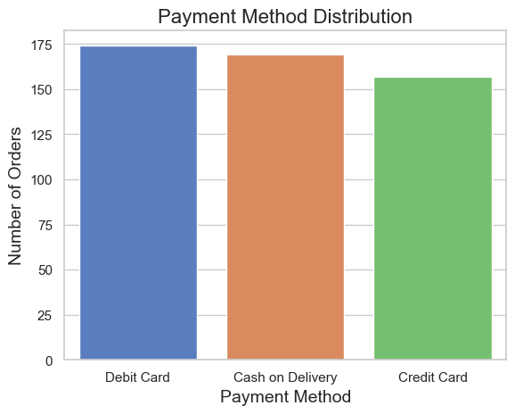

```python
import warnings

# Ignore specific warning messages
warnings.filterwarnings("ignore", category=FutureWarning)

# The rest of your plotting code
sns.set(style="whitegrid")

# Creating the bar plot with hue set to None and legend disabled
sns.barplot(x=payment_counts.index, y=payment_counts.values, palette="muted", hue=None, legend=False)

# Adding labels and title
plt.title('Payment Method Distribution', fontsize=16)
plt.xlabel('Payment Method', fontsize=14)
plt.ylabel('Number of Orders', fontsize=14)

# Showing the plot
plt.show()

# Re-enable warnings if needed
warnings.filterwarnings("default", category=FutureWarning)
```

### 4.1.3. Findings Documentation

**Findings**  
From the data, it appears that Debit Card is the most frequently used payment method, followed closely by Cash on Delivery and then Credit Card.

**Business Implications**  
Given that Debit Card and Cash on Delivery are popular, the business might consider focusing on optimizing these payment methods. For example:

- Ensuring the Debit Card payment process is smooth and secure, as this is the most used method.
- Streamlining the Cash on Delivery process to minimize delays and errors.

The company might consider targeted promotions or incentives for using less popular payment methods like Credit Cards, to balance the usage across different methods.

**Limitations**

- *Small Dataset:* The analysis is based on a relatively small dataset of 500 records. As a result, the differences in payment method usage might not be statistically significant. In a real-world scenario with a larger dataset, the results might differ.
- *Lack of Contextual Data:* The dataset does not provide information about the reasons behind the payment method choices, such as user preferences, regional differences, or economic factors, which could impact the results.
- *Potential Sampling Bias:* If this data is not representative of the entire customer base, the conclusions drawn may not generalize to all customers.

**Recommendations**

- *Further Analysis with Larger Dataset:* To draw more reliable conclusions, it would be beneficial to perform the same analysis on a larger and more diverse dataset.
- *User Experience Survey:* Conducting surveys or interviews with customers could provide insights into why they prefer certain payment methods, which could further inform business strategies.

## 4.2. When Do Customers Order More in a Day?

This question aims to identify the time periods during the day when customers are most likely to place their orders. Understanding this can help optimize staffing, promotions, and service during peak hours. The data will be analyzed to determine if there are specific hours or periods that show a higher frequency of orders.

### 4.2.1. Data Exploration

In this step, the Order Date column will be explored to identify patterns in order frequency throughout the day. Specifically, the distribution of orders across different times of the day will be analyzed to determine when customers are most likely to place their orders.

```python
#Extracting the hour from the 'Order Date' column
df_orders['Order Hour'] = df_orders['Order Date'].dt.hour
print("Order Hour column added:")
print(df_orders[['Order Date', 'Order Hour']].head())
```

```
Order Hour column added:
           Order Date  Order Hour
0 2022-01-01 23:15:00          23
1 2022-01-01 19:21:00          19
2 2022-01-01 23:15:00          23
3 2022-01-01 20:31:00          20
4 2022-01-01 11:10:00          11
```

```python
# Counting the number of orders per hour
order_counts_per_hour = df_orders['Order Hour'].value_counts().sort_index()
print("\nNumber of Orders per Hour:")
print(order_counts_per_hour)
```

```
Number of Orders per Hour:
Order Hour
11    73
12    41
13    54
14    99
15    23
17    20
18    18
19    31
20    49
21    31
22    15
23    46
Name: count, dtype: int64
```

### 4.2.2. Visualization

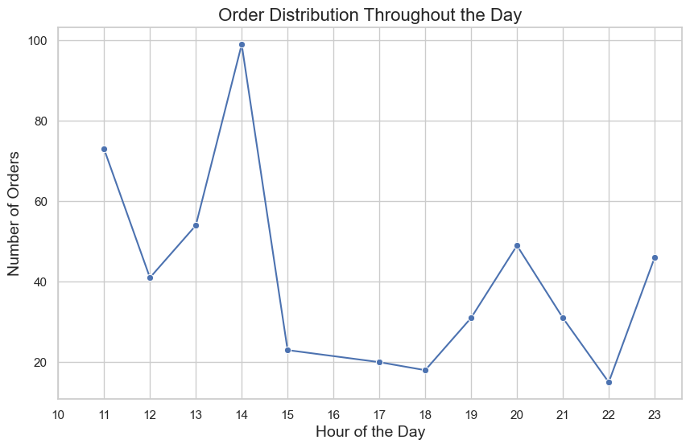

```python
# Visualizing the distribution of orders throughout the day with a focused x-axis
plt.figure(figsize=(10, 6))
sns.lineplot(x=order_counts_per_hour.index, y=order_counts_per_hour.values, marker="o", color="b")
plt.title('Order Distribution Throughout the Day', fontsize=16)
plt.xlabel('Hour of the Day', fontsize=14)
plt.ylabel('Number of Orders', fontsize=14)
plt.xticks(range(10, 24))  # Adjusting the x-axis to start from 10 and end at 23
plt.grid(True)
plt.show()
```

### 4.2.3. Findings Documentation

**Findings**  
From the data, it is observed that customer orders peak at around 14:00, followed by a significant drop and then smaller peaks in the evening hours around 19:00 to 21:00. The least orders are placed during early morning hours (00:00 - 09:00).

**Limitations**

- *Small Dataset:* The analysis is based on a relatively small dataset of 500 records. A larger dataset might reveal different order patterns or confirm the existing trend with more confidence.
- *Time-bound Data:* The dataset represents a specific timeframe. If this data is not representative of typical daily patterns (e.g., weekdays vs. weekends), the conclusions might not generalize well.
- *Lack of Contextual Information:* The dataset doesn’t account for external factors like holidays, promotions, or special events, which could significantly affect order times.

**Recommendations**

- Further Analysis with a Larger Dataset: Repeating this analysis with a larger, more comprehensive dataset could provide more reliable insights and account for any seasonal or daily variations.
- Conducting A/B Testing: Implementing targeted campaigns during off-peak hours and testing their effectiveness could help increase orders during those times.
- Collecting and Analyzing Contextual Data: Gathering additional data on holidays, promotions, or customer preferences could provide a more nuanced understanding of order patterns and inform better business strategies.

## 4.3. What is the Average Order Amount per Customer and Does it Vary by Zone?

This analysis aims to determine the average order amount per customer and explore whether this amount varies across different zones. Understanding these patterns can provide insights into customer behavior in different regions, helping to tailor marketing strategies and optimize pricing models based on location.

### 4.3.1. Data Exploration

In this step, the average order amount per customer will be calculated and examined across various zones. This involves aggregating the data to obtain the average order amounts and then analyzing these averages by different zones to uncover any significant patterns or discrepancies.

```python
# Step 1: Merging the 'Zone' column from df_rest into df_orders
df_orders = pd.merge(df_orders, df_rest[['RestaurantID', 'Zone']], left_on='Restaurant ID', right_on='RestaurantID', how='left')
```

```python
# Step 2: Calculating the total order amount per customer
total_order_per_customer = df_orders.groupby('Customer Name')['Order Amount'].sum()
print("Total Order Amount per Customer:")
print(total_order_per_customer.head())
```

```
Total Order Amount per Customer:
Customer Name
Charlie    16180
Chinny     11489
David      15574
Dev        13306
Farhan     16392
Name: Order Amount, dtype: int64
```

```python
# Step 3: Calculating the number of orders per customer
num_orders_per_customer = df_orders.groupby('Customer Name')['Order Amount'].count()
print("\nNumber of Orders per Customer:")
print(num_orders_per_customer.head())
```

```
Number of Orders per Customer:
Customer Name
Charlie    24
Chinny     19
David      24
Dev        24
Farhan     25
Name: Order Amount, dtype: int64
```

```python
# Step 4: Calculating the average order amount per customer
avg_order_per_customer = total_order_per_customer / num_orders_per_customer
print("\nAverage Order Amount per Customer:")
print(avg_order_per_customer.head())
```

```
Average Order Amount per Customer:
Customer Name
Charlie    674.166667
Chinny     604.684211
David      648.916667
Dev        554.416667
Farhan     655.680000
Name: Order Amount, dtype: float64
```

```python
# Step 5: Merging the average order amount back into df_orders
df_orders = df_orders.merge(avg_order_per_customer.rename('Avg Order Amount'), on='Customer Name')
print("\nUpdated DataFrame with Average Order Amount per Customer:")
print(df_orders[['Customer Name', 'Avg Order Amount', 'Zone']].head())
```

```
Updated DataFrame with Average Order Amount per Customer:
  Customer Name  Avg Order Amount    Zone
0         Srini        598.382353  Zone D
1       Revandh        600.200000  Zone D
2         David        648.916667  Zone D
3         Selva        517.000000  Zone D
4         Vinny        662.909091  Zone D
```

```python
# Step 6: Calculating the average order amount per customer by zone
avg_order_per_zone = df_orders.groupby('Zone')['Avg Order Amount'].mean()
print("\nAverage Order Amount per Customer by Zone:")
print(avg_order_per_zone)
```

```
Average Order Amount per Customer by Zone:
Zone
Zone A    597.549267
Zone B    598.070163
Zone C    594.560180
Zone D    599.824712
Name: Avg Order Amount, dtype: float64
```

### 4.3.2. Visualization

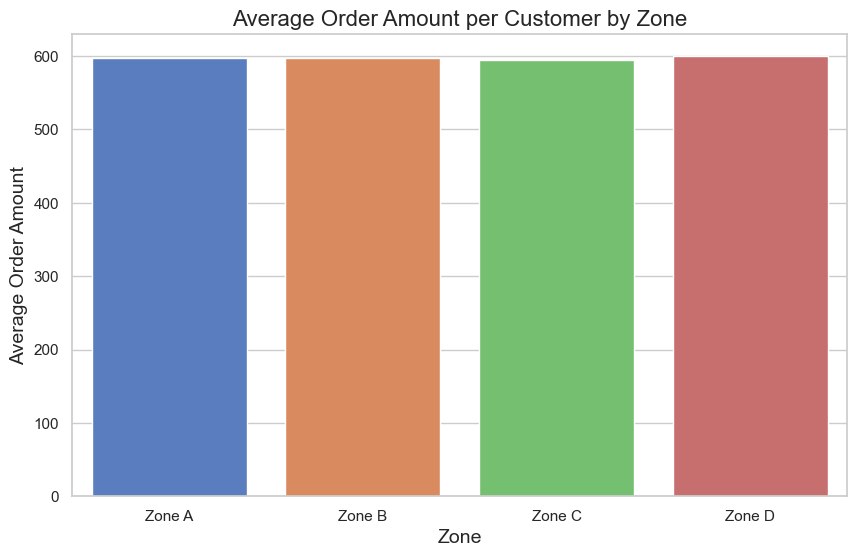

```python
# Ignore specific warning messages
warnings.filterwarnings("ignore", category=FutureWarning)

# Visualizing the average order amount per customer by zone
plt.figure(figsize=(10, 6))
sns.barplot(x=avg_order_per_zone.index, y=avg_order_per_zone.values, palette="muted")

# Add labels and title
plt.title('Average Order Amount per Customer by Zone', fontsize=16)
plt.xlabel('Zone', fontsize=14)
plt.ylabel('Average Order Amount', fontsize=14)

# Show the plot
plt.show()
```

### 4.3.3. Findings Documentation

**Findings**  
The analysis reveals that the average order amount per customer is quite consistent across all zones, with no significant differences observed. Each zone shows a similar average order amount, indicating uniform spending behavior across different geographical areas.

**Business Implications**  
The consistency in average order amounts across zones suggests that customer spending is stable regardless of location. This uniformity can simplify pricing strategies and promotions, as there may not be a need to tailor them specifically for different zones. However, the business could consider investigating further to understand if this uniformity is due to similar demographics, effective pricing strategies, or other factors.

**Limitations**

- *Small Dataset:* The analysis is based on a dataset of 500 records, which may not be representative of the entire customer base. As a result, the findings may not be statistically significant.
- *Lack of Customer IDs:* The dataset only contains customer names, which are likely to be non-unique. This can lead to inaccuracies in calculating the average order amount per customer. In a real-world scenario, using a unique customer ID would provide more accurate results.
- *Possible Data Limitations:* The dataset might lack certain contextual factors that could influence spending behavior, such as promotions, seasonality, or customer segmentation.

**Recommendations**

- *Use of Unique Identifiers:* For more accurate customer-based analysis, ensure that datasets include unique customer identifiers. This would avoid errors caused by non-unique customer names.
- *Further Analysis with Larger Dataset:* Conduct the same analysis on a larger and more diverse dataset to confirm the findings and ensure they are statistically significant.
- *Contextual Analysis:* Consider incorporating additional data points, such as demographic information or promotional data, to understand the factors driving spending behavior across different zones.

## 4.4. How Do Order Amounts Vary Across Different Cuisines?

In this step, the variation in order amounts depending on the type of cuisine will be explored. This insight could help the business understand customer preferences and potentially tailor marketing strategies to encourage higher spending on specific cuisines.

### 4.4.1. Data Exploration

In this step, the data will be examined to identify any differences in order amounts across different types of cuisines. By grouping the data by cuisine and calculating the average order amount, it is possible to determine which cuisines tend to generate higher orders.

```python
# Dropping the redundant 'RestaurantID' from df_orders before merging
df_orders = df_orders.drop(columns=['RestaurantID'])

# Merging the 'Cuisine' column from df_rest into df_orders
df_orders = pd.merge(df_orders, df_rest[['RestaurantID', 'Cuisine']], left_on='Restaurant ID', right_on='RestaurantID', how='left')

# Calculating the average order amount by cuisine
avg_order_per_cuisine = df_orders.groupby('Cuisine')['Order Amount'].mean()
print("\nAverage Order Amount per Cuisine:")
print(avg_order_per_cuisine)
```

```
Average Order Amount per Cuisine:
Cuisine
African         597.573770
Arabian         664.880000
Belgian         624.928571
Chinese         560.950617
Continental     634.218182
French          635.507042
North Indian    576.617284
South Indian    555.071429
Name: Order Amount, dtype: float64
```

### 4.4.2. Visualization

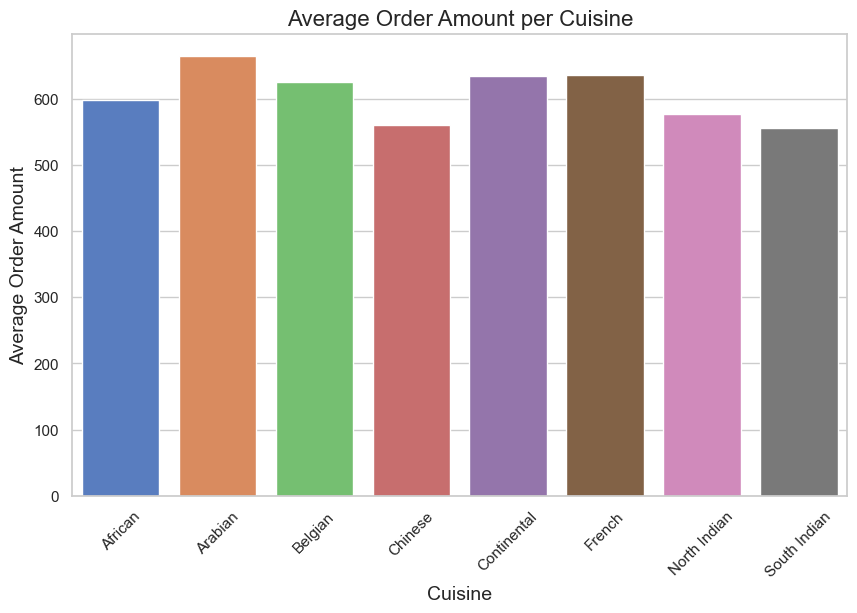

```python
# Ignore specific warning messages
warnings.filterwarnings("ignore", category=FutureWarning)

# Visualizing the average order amount per cuisine
plt.figure(figsize=(10, 6))
sns.barplot(x=avg_order_per_cuisine.index, y=avg_order_per_cuisine.values, palette="muted")

# Add labels and title
plt.title('Average Order Amount per Cuisine', fontsize=16)
plt.xlabel('Cuisine', fontsize=14)
plt.ylabel('Average Order Amount', fontsize=14)
plt.xticks(rotation=45)
plt.show()
```

### 4.4.3. Findings Documentation

**Business Implications**  
Given that the average order amount does not significantly vary across cuisines, the business might not need to prioritize certain cuisines over others when designing pricing strategies or promotional offers. Instead, they could focus on other factors such as customer satisfaction, delivery efficiency, or expanding the variety of cuisines offered

**Limitations**

- *Small Dataset:* The analysis is based on a limited dataset of 500 records. The consistency observed in average order amounts across cuisines might not hold true with a larger, more diverse dataset.
- *Lack of Customer Segmentation:* The dataset does not account for customer preferences or demographics, which could affect spending habits. Different customer segments might exhibit different spending behaviors based on the type of cuisine.
- *Potential Data Overlap:* As discussed earlier, the dataset uses customer names instead of unique identifiers, which could lead to inaccuracies if multiple customers share the same name. This limitation could affect the accuracy of the average order calculations.
- *Limited Context:* The dataset does not provide information on other factors that might influence order amounts, such as special promotions, holidays, or economic conditions. These factors could result in variations in order amounts that are not captured in the current analysis.

**Recommendations**

- *Larger Dataset Analysis:* To gain more reliable insights, it is recommended to perform this analysis on a larger and more representative dataset. This would help to confirm or refute the findings observed here.
- *Incorporate Customer Segmentation:* Including customer segmentation in future analyses could provide more detailed insights into spending patterns across different demographics or customer types.
- *Use Unique Identifiers:* For future datasets, it is advisable to include unique customer identifiers rather than relying on names. This would improve the accuracy of customer-specific analyses and reduce potential data overlap.
- *Contextual Data:* Collecting and analyzing data on factors like promotions, holidays, or customer feedback could provide a more comprehensive understanding of what drives order amounts for different cuisines.

## 4.5. Is There a Relationship Between In-Demand Restaurants and In-Demand Cuisine?

This analysis aims to explore the relationship between the popularity of certain restaurants and the types of cuisines they offer. Investigating this relationship may identify patterns or trends that influence restaurant demand based on cuisine type, providing valuable insights for businesses in strategizing menu offerings and marketing efforts.

### 4.5.1. Data Exploration

To explore the relationship between restaurant popularity and the type of cuisine offered, the distribution of orders across different restaurants and cuisines will be analyzed. This step involves checking the dataset for relevant patterns that might reveal how certain cuisines are associated with more popular restaurants.

```python
# Merging the 'Cuisine' column from df_rest into df_orders
df_orders = pd.merge(df_orders, df_rest[['RestaurantID', 'Cuisine']], left_on='Restaurant ID', right_on='RestaurantID', how='left')

# Print the first few rows of df_orders to confirm the merge
print("DataFrame after merging Cuisine information:")
print(df_orders.head())
```

```
DataFrame after merging Cuisine information:
  Order ID Customer Name  Restaurant ID          Order Date  \
0      OD1         Srini              6 2022-01-01 23:15:00
1      OD2       Revandh             13 2022-01-01 19:21:00
2      OD3         David              9 2022-01-01 23:15:00
3      OD4         Selva              4 2022-01-01 20:31:00
4      OD5         Vinny              4 2022-01-01 11:10:00

   Quantity of Items  Order Amount      Payment Mode  \
0                  5           633        Debit Card
1                  5           258       Credit Card
2                  7           594  Cash on Delivery
3                  5           868  Cash on Delivery
4                  4           170        Debit Card

```

[output cut: 20 more lines]

```python
# Calculating the number of orders per cuisine
orders_per_cuisine = df_orders['Cuisine'].value_counts()
print("\nNumber of Orders per Cuisine:")
print(orders_per_cuisine)
```

```
Number of Orders per Cuisine:
Cuisine
Chinese         81
North Indian    81
French          71
South Indian    70
African         61
Belgian         56
Continental     55
Arabian         25
Name: count, dtype: int64
```

```python
# Calculating the number of orders per restaurant
orders_per_restaurant = df_orders['Restaurant ID'].value_counts()
print("\nNumber of Orders per Restaurant:")
print(orders_per_restaurant)
```

```
Number of Orders per Restaurant:
Restaurant ID
18    32
1     32
20    31
6     30
16    29
13    29
12    28
4     27
17    25
19    25
14    24
3     23
8     23
5     23
9     23
7     22
2     20
10    20
11    18
15    16
Name: count, dtype: int64
```

```python
# Merging the orders per restaurant with the cuisine information
orders_per_restaurant_df = orders_per_restaurant.reset_index()
orders_per_restaurant_df.columns = ['Restaurant ID', 'Orders Count']

merged_df = pd.merge(orders_per_restaurant_df, df_rest[['RestaurantID', 'Cuisine']], left_on='Restaurant ID', right_on='RestaurantID', how='left')
```

```python
# Calculating the average number of orders per cuisine
average_orders_per_cuisine = merged_df.groupby('Cuisine')['Orders Count'].mean()
print("\nAverage Orders per Cuisine:")
print(average_orders_per_cuisine)
```

```
Average Orders per Cuisine:
Cuisine
African         30.500000
Arabian         25.000000
Belgian         28.000000
Chinese         27.000000
Continental     27.500000
French          23.666667
North Indian    20.250000
South Indian    23.333333
Name: Orders Count, dtype: float64
```

### 4.5.2. Visualization

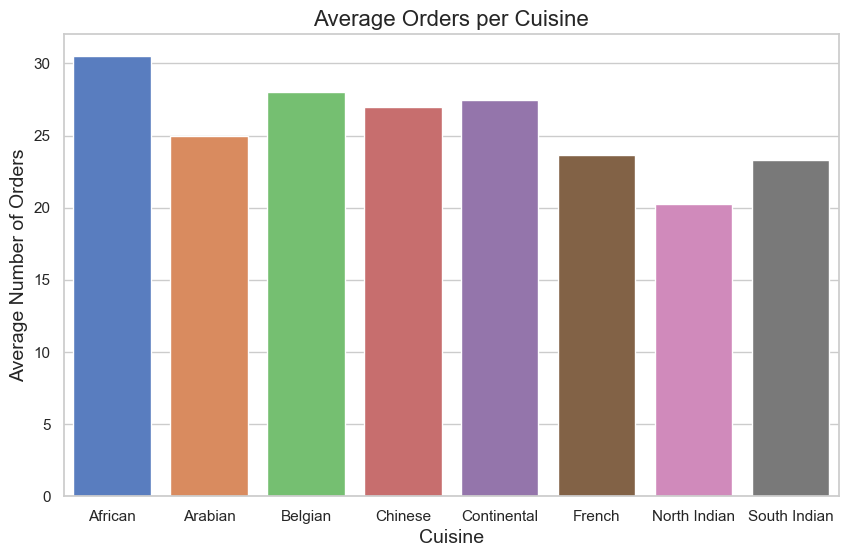

```python
# Ignore specific warning messages
warnings.filterwarnings("ignore", category=FutureWarning)

# Visualizing the average number of orders per cuisine
plt.figure(figsize=(10, 6))
sns.barplot(x=average_orders_per_cuisine.index, y=average_orders_per_cuisine.values, palette="muted")

# Add labels and title
plt.title('Average Orders per Cuisine', fontsize=16)
plt.xlabel('Cuisine', fontsize=14)
plt.ylabel('Average Number of Orders', fontsize=14)

# Show the plot
plt.show()
```

### 4.5.3. Findings Documentation

**Limitations**

- *Dataset Size:* The conclusions are drawn from a relatively small dataset, which might not fully capture the broader trends in customer preferences. The small sample size could affect the reliability of the results.
- *Lack of Context:* The dataset does not provide context on why certain cuisines are more popular. Factors like cultural preferences, time of year, or even the specific dishes offered within each cuisine category are not considered.
- *Customer Overlap:* The dataset assumes that each order is independent, but there might be repeat customers whose preferences could skew the results.

**Recommendations**

- *Further Analysis:* Consider analyzing a larger dataset to confirm these findings and ensure they are representative of the entire customer base.
- *Customer Surveys:* Conduct surveys to understand the reasons behind customers' preferences for certain cuisines. This information could provide deeper insights that are not captured in the dataset.
- *Promotional Strategies:* Test different promotional strategies for less popular cuisines to see if targeted marketing can increase their demand.

## 4.6. What Is the Relationship Between Delivery Time and Customer Satisfaction (Ratings)?

This analysis explores the relationship between delivery time and customer satisfaction. By examining this relationship, it is possible to identify whether faster delivery times are associated with higher customer ratings. This insight could be valuable for improving customer satisfaction by optimizing delivery processes.

### 4.6.1. Data Exploration

In this section, the relationship between delivery time and customer satisfaction will be examined by analyzing the delivery time taken for each order and the corresponding customer ratings. This analysis will help identify any patterns or correlations between how quickly orders are delivered and the satisfaction levels of customers.

```python
# Calculating the average customer rating for each delivery time
avg_rating_per_delivery_time = df_orders.groupby('Delivery Time Taken (mins)')['Customer Rating-Delivery'].mean()
print("\nAverage Customer Rating by Delivery Time (in minutes):")
print(avg_rating_per_delivery_time.head())
```

```
Average Customer Rating by Delivery Time (in minutes):
Delivery Time Taken (mins)
10    3.555556
11    3.272727
12    3.333333
13    2.846154
14    2.250000
Name: Customer Rating-Delivery, dtype: float64
```

### 4.6.2. Visualization

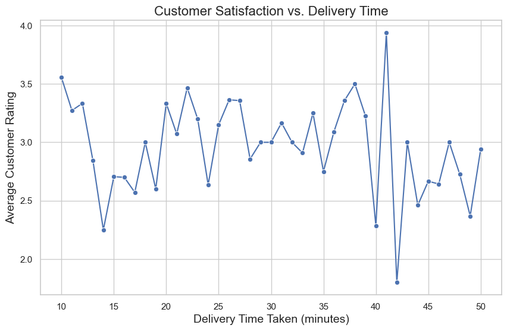

```python
# Visualizing the relationship between delivery time and customer satisfaction
plt.figure(figsize=(10, 6))
sns.lineplot(x=avg_rating_per_delivery_time.index, y=avg_rating_per_delivery_time.values, marker="o", color="b")

plt.title('Customer Satisfaction vs. Delivery Time', fontsize=16)
plt.xlabel('Delivery Time Taken (minutes)', fontsize=14)
plt.ylabel('Average Customer Rating', fontsize=14)
plt.grid(True)

plt.show()
```

### 4.6.3. Findings Documentation

**Findings**  
The data indicates variability in customer satisfaction based on delivery times. While shorter delivery times generally correlate with higher average customer ratings, there are fluctuations that suggest other factors might also influence customer satisfaction. Interestingly, certain longer delivery times also received relatively high ratings, showing that customers might have different expectations based on context.

**Business Implication**  
Understanding the relationship between delivery time and customer satisfaction is crucial for improving service quality. If quicker deliveries tend to result in higher satisfaction, businesses might focus on optimizing delivery processes. However, the fluctuation in ratings suggests that other factors, such as food quality or communication during delays, might also play significant roles in determining customer satisfaction.

**Limitation**  
The analysis assumes a linear relationship between delivery time and customer satisfaction. However, the fluctuations observed suggest that the relationship might be more complex. Additionally, the dataset does not account for factors such as weather conditions, traffic, or delivery distance, which could impact delivery time and customer satisfaction.

**Recommendations**

- *Investigate Other Factors:* Future analyses could incorporate other variables, such as food quality ratings, weather conditions, and distance, to get a more comprehensive understanding of what impacts customer satisfaction.
- *Communication During Delays:* If delays are unavoidable, ensuring clear and timely communication with customers could help maintain higher satisfaction levels.
- *Personalized Delivery Experience:* Consider implementing options where customers can choose their preferred delivery window, even if it means waiting longer, to improve their overall satisfaction.